# MEDB 5505, Module03

2025-02-01

## Topics to be covered

- What you will learn
  - Reading text files
  - Comma delimited files
  - Tab delimited files
  - Other delimiters
  - Fixed width files
  - Special cases
  - Your programming assignment

## Text files, 1

- Advantages
  - Easy import into many programs
  - Review using notepad
- Disadvantages
  - Bigger size
  - Slower to import

## Text files, 2

- Wide range of formats
  - Delimited
  - Fixed width
- First row for variable names
  - Optional but recommended
- Always look for a data dictionary

## Should I download before reading?

- Read directly from website
  - Convenient
  - Updates incorporated at each run
- Download then read
  - Downloaded file doesn’t disappear
  - Avoid repeated long downloads
  - Work even when Internet connection is down

## No data dictionary?

- Peek at file
  - Same number of delimiters on each line
  - Tabs versus multiple blanks are hard to distinguish
- http://www.pmean.com/12/pesky.html

## No data dictionary?

- Experiment
  - Read warnings carefully
- If needed, edit the file manually
  - Simple edits of one or two offending lines
  - Global search and replace
  - Change tabs to blanks
  - Change multiple blanks to single blank

## Troubleshooting

- Multiple data read in as single variable.
- Lots of missing values

## Break #1

- What you have learned
  - Reading text files
- What’s coming next
  - Comma delimited files

## An example of a comma delimited file

```
x,y
1,4
2,8
3,12
4,16
```

## the read_csv function

```
raw_data <- read_csv(
  file="../data/simple.csv",
  col_names=TRUE,
  col_types="nn")

glimpse(raw_data)
```

## Live demonstration, 1

Now, you will see a live demonstration of the program [simon-5505-02-demo-02](https://github.com/pmean/classes/blob/master/introduction-to-r/03/src/simon-5505-03-demo-02.qmd).

## Break #2

- What you have learned
  - Comma delimited files
- What’s coming next
  - Tab delimited files

## Tab delimited files

```
x   y
1   4
2   8
3   12
4   16
```

## Using the read_tsv function

```
raw_data <- read_tsv(
  file="../data/simple.tsv",
  col_names=TRUE,
  col_types="nn")

glimpse(raw_data)
```

## Live demonstration, 2

Now, you will see a live demonstration of the program [simon-5505-03-demo-03](https://github.com/pmean/classes/blob/master/introduction-to-r/03/src/simon-5505-03-demo-03.qmd).

## Break #3

- What you have learned
  - Tab delimited files
- What’s coming next
  - Other delimiters

## Anything can be a delimiter

```
x~y
1~4
2~8
3~12
4~16
```

## Using the read_delim function with delim=“~”

```
raw_data <- read_delim(
  file="../data/tilde.txt",
  delim="~",
  col_names=TRUE,
  col_types="nn")

glimpse(raw_data)
```

## Live demonstration, 3

Now, you will see a live demonstration of the program [simon-5505-03-demo-04](https://github.com/pmean/classes/blob/master/introduction-to-r/03/src/simon-5505-03-demo-04.qmd).

## Break #4

- What you have learned
  - Other delimiters
- What’s coming next
  - Fixed width files

## Reading fixed width format files

```
1 4
2 8
312
416
```

## The read_fwf function

```
raw_data <- read_fwf(
  file="../data/fixed.txt",
  col_names=c("x", "y"),
  col_positions = fwf_cols(1, 2),
  col_types="nn")

glimpse(raw_data)
```

## Helpful functions with read_fwf

- fwf_empty()
  - Uses spacing to guess at column positions
- fwf_widths()
  - Specifies column widths
- fwf_positions()
  - Specifies start and end locations for each column

## Disadvantages of fixed width formatting?

- Confusing
  - What is 312?
    - 3, 1, and 2?
    - 31 and 2?
    - 3 and 12?
    - 312?
- More work
- Prone to errors

## Example where fixed width formatting is needed.

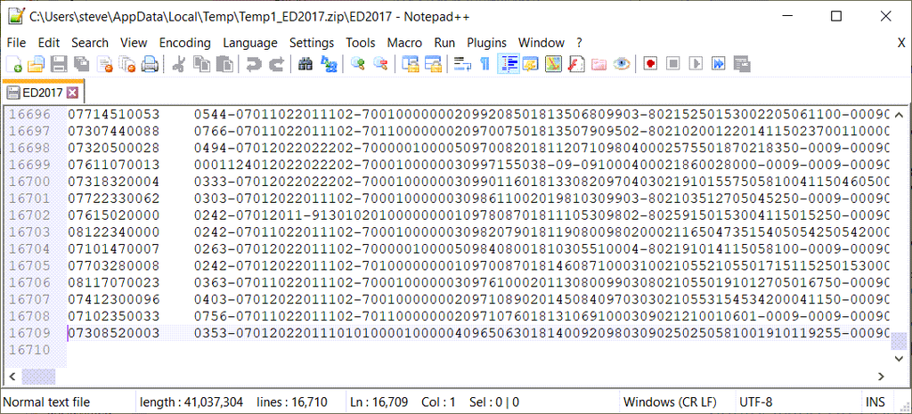

## Live demonstration, 4

Now, you will see a live demonstration of the program [simon-5505-02-demo-05](https://github.com/pmean/classes/blob/master/introduction-to-r/03/src/simon-5505-03-demo-05.qmd).

## Break #5

- What you have learned
  - Fixed width files
- What’s coming next
  - Special cases

## Function arguments for advanced options

- col_select=
- na=
- name_repair=
- skip=

## Example #1, binary.csv

[figure not shown]

Figure 1. Excerpt from website

## Example #1, the data

```
admit,gre,gpa,rank
0,380,3.61,3
1,660,3.67,3
1,800,4,1
1,640,3.19,4
0,520,2.93,4
```

## Example #1, the data dictionary

- No formal data dictionary, but here is a description
  - “This dataset has a binary response (outcome, dependent) variable called admit. There are three predictor variables: gre, gpa and rank. We will treat the variables gre and gpa as continuous. The variable rank takes on the values 1 through 4. Institutions with a rank of 1 have the highest prestige, while those with a rank of 4 have the lowest.”

## Example #1, the output

```
# A tibble: 400 × 4
   admit   gre   gpa  rank
   <dbl> <dbl> <dbl> <dbl>
 1     0   380  3.61     3
 2     1   660  3.67     3
 3     1   800  4        1
 4     1   640  3.19     4
 5     0   520  2.93     4
 6     1   760  3        2
 7     1   560  2.98     1
 8     0   400  3.08     2
 9     1   540  3.39     3
10     0   700  3.92     2
# ℹ 390 more rows
```

## Example #2, barbershop-music.txt

[figure not shown]

Figure 2. Excerpt from website

## Example #2, the data file

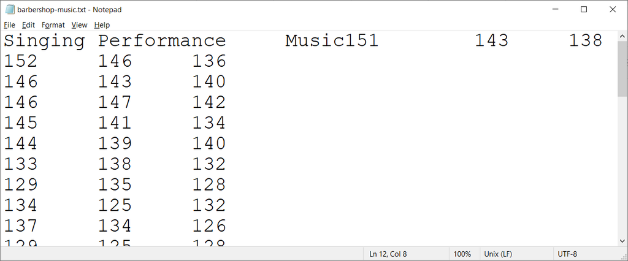

## Example #2, the data file, fixed

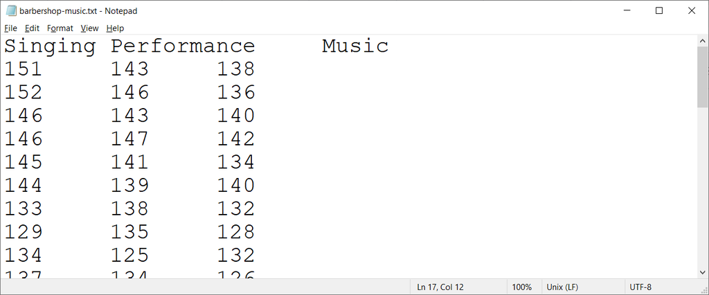

## Example #2, the data dictionary

- No data dictionary
  - Brief description: “At a barbershop music singing competition, choruses are judged on three scales: Music (quality of the arrangement, etc.), Performance, and Singing.”

## Example #2, the output

```
# A tibble: 34 × 3
   Singing Performance Music
     <dbl>       <dbl> <dbl>
 1     151         143   138
 2     152         146   136
 3     146         143   140
 4     146         147   142
 5     145         141   134
 6     144         139   140
 7     133         138   132
 8     129         135   128
 9     134         125   132
10     137         134   126
# ℹ 24 more rows
```

## Example #3, airport.txt

[figure not shown]

Figure 3. Excerpt from website

## Example #3, the data file

[figure not shown]

## Example #3, the data dictionary

- Here is an excerpt from the data dictionary.

```
VARIABLE DESCRIPTIONS:
Airport                          Columns 1-21
City                             Columns 22-43
Scheduled departures             Columns 44-49
```

## Example #3, the output

```
# A tibble: 135 × 7
   X1                   X2                  X3     X4       X5      X6      X7
   <chr>                <chr>            <dbl>  <dbl>    <dbl>   <dbl>   <dbl>
 1 HARTSFIELD INTL      ATLANTA         285693 288803 22665665 165669.  93039.
 2 BALTO/WASH INTL      BALTIMORE        73300  74048  4420425  18042.  19723.
 3 LOGAN INTL           BOSTON          114153 115524  9549585 127815.  29786.
 4 DOUGLAS MUNI         CHARLOTTE       120210 121798  7076954  36243.  15399.
 5 MIDWAY               CHICAGO          64465  66389  3547040   4495.   4486.
 6 O'HARE INTL          CHICAGO         322430 332338 25636383 300464. 140359.
 7 DALLAS/FT WORTH INTL DALLAS/FT WORTH 266737 269665 22899267 142661.  86707.
 8 LOVE FIELD           DALLAS/FT WORTH  39481  40196  2882836   2217.    243.
 9 STAPLETON INTL       DENVER          154067 156293 11961839  67346.  38044.
10 DETROIT CITY         DETROIT           6828   7162   362655    258.      0
# ℹ 125 more rows
```

## Links for examples 1-3

Data file links

1. https://stats.idre.ucla.edu/stat/data/binary.csv
2. https://dasl.datadescription.com/download/data/3061
3. http://jse.amstat.org/datasets/airport.dat.txt

Data dictionary links

1. https://stats.idre.ucla.edu/r/dae/logit-regression/
2. https://dasl.datadescription.com/datafile/barbershop-music/
3. http://jse.amstat.org/datasets/airport.txt

## Break #6

- What you have learned
  - Special cases
- What’s coming next
  - Your programming assignment

This programming assignment was written by Steve Simon on 2024-12-18 and is placed in the public domain.

## Data

- Download the [data](https://github.com/pmean/data/blob/main/files/aids-cases.csv) file
  - Store it in your data folder
- Refer to the [data dictionary](https://github.com/pmean/data/blob/main/files/aids-cases.yaml), if needed.

## Grading rubric

You will be evaluated using the [general grading rubric for programming assignments](https://github.com/pmean/classes/blob/master/general/general-grading-rubric.md).

## Your submission

- Save the output in html format
- Convert it to pdf format.
- Make sure that the pdf file includes
  - Your last name
  - The number of this course
  - The number of this module
- Upload the file

## If it doesn’t work

Please review the [suggestions if you encounter an error page](https://github.com/pmean/classes/blob/master/general/suggestions-if-you-encounter-an-error.md).

## Summary

- What you have learned
  - Reading text files
  - Comma delimited files
  - Tab delimited files
  - Other delimiters
  - Fixed width files
  - Special cases
  - Your programming assignment